# Predicting Chance of Diabetes Deep Learning Regression

## Exploratory Data Analysis (EDA)

```python
# data.describe().T
```

```python
data1 = data.describe().T
data1['ratio'] = data1['std'] / data1['mean']
data1['skew'] = data1['std'] / data1['mean']
data1.sort_values(by='ratio', ascending=False)
```

|  | count | mean | std | min | 25% | 50% | 75% | max | ratio | skew |
| --- | --- | --- | --- | --- | --- | --- | --- | --- | --- | --- |
| Insulin | 768.0 | 79.799479 | 115.244002 | 0.000 | 0.00000 | 30.5000 | 127.25000 | 846.00 | 1.444170 | 1.444170 |
| Outcome | 768.0 | 0.348958 | 0.476951 | 0.000 | 0.00000 | 0.0000 | 1.00000 | 1.00 | 1.366786 | 1.366786 |
| Pregnancies | 768.0 | 3.845052 | 3.369578 | 0.000 | 1.00000 | 3.0000 | 6.00000 | 17.00 | 0.876341 | 0.876341 |
| SkinThickness | 768.0 | 20.536458 | 15.952218 | 0.000 | 0.00000 | 23.0000 | 32.00000 | 99.00 | 0.776775 | 0.776775 |
| DiabetesPedigreeFunction | 768.0 | 0.471876 | 0.331329 | 0.078 | 0.24375 | 0.3725 | 0.62625 | 2.42 | 0.702151 | 0.702151 |
| Age | 768.0 | 33.240885 | 11.760232 | 21.000 | 24.00000 | 29.0000 | 41.00000 | 81.00 | 0.353788 | 0.353788 |
| BloodPressure | 768.0 | 69.105469 | 19.355807 | 0.000 | 62.00000 | 72.0000 | 80.00000 | 122.00 | 0.280091 | 0.280091 |
| Glucose | 768.0 | 120.894531 | 31.972618 | 0.000 | 99.00000 | 117.0000 | 140.25000 | 199.00 | 0.264467 | 0.264467 |
| BMI | 768.0 | 31.992578 | 7.884160 | 0.000 | 27.30000 | 32.0000 | 36.60000 | 67.10 | 0.246437 | 0.246437 |

- Observations
  - Insulin, Outcome, Pregnancies, and SkinThickness show higher variability and skew, requiring:
    - Distribution checks
    - Outlier handling
    - Possible feature engineering
- Glucose and BMI are stable, well-behaved predictors.

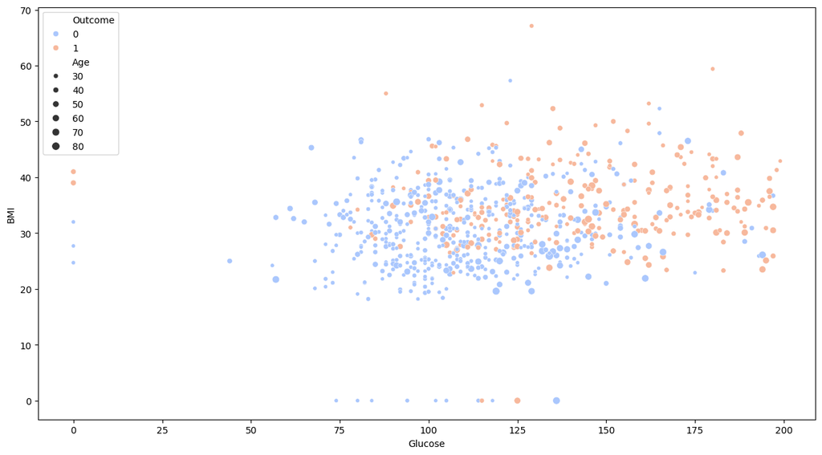

```python
plt.figure(figsize=(15, 8))
sns.scatterplot(
    data=data,
    x='Glucose', # Key feature correlated with diabetes
    y='BMI', # shows strong trends
    hue='Outcome',           # Target (0 = No Diabetes, 1 = Diabetes)
    size='Age',              # Optional — adds another variable visually
    palette='coolwarm'
)
```

- Observations
  - Higher Glucose levels are strongly associated with diabetes (more orange points right of 125).
  - BMI is moderately related; diabetic cases cluster around BMI 30–45.
  - Low Glucose (<110) mostly shows non-diabetic outcomes.
  - Age (size) doesn’t clearly separate classes but adds context.
  - Some outliers exist near zero values for Glucose/BMI.

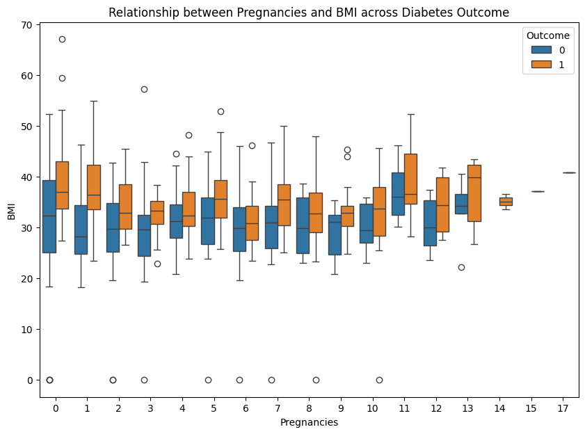

```python
plt.figure(figsize=(10, 7))
sns.boxplot(data=data,
            x='Pregnancies',
            y='BMI',
            hue='Outcome')  # 0 or 1
plt.title('Relationship between Pregnancies and BMI across Diabetes Outcome')
plt.show()
```

- Observations
  - Higher BMI is generally observed in patients with more pregnancies who are diabetic (Outcome = 1), suggesting a possible link.
  - Variation in BMI increases with pregnancy count, especially for diabetic individuals.
  - Non-diabetic individuals (Outcome = 0) show more consistent BMI across pregnancy levels.

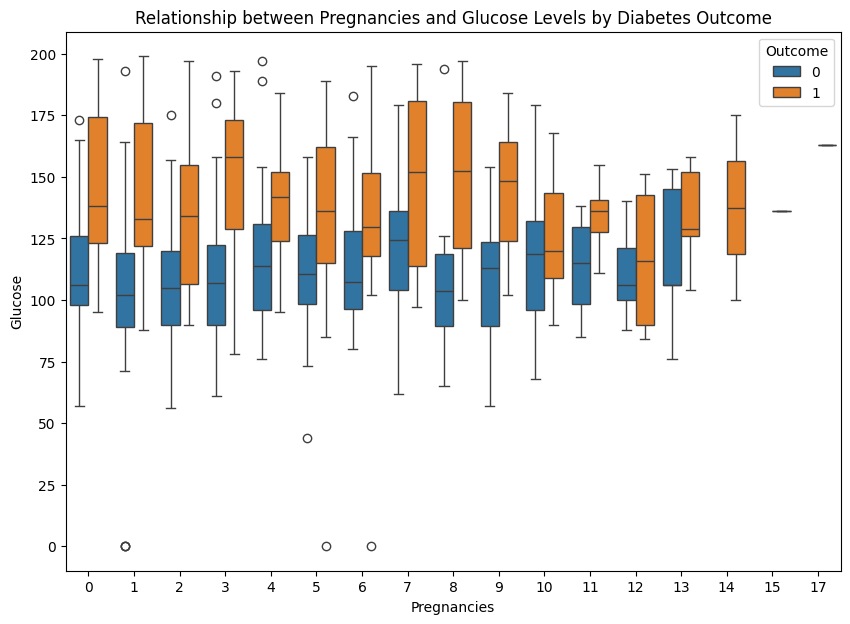

```python
plt.figure(figsize=(10, 7))
sns.boxplot(data=data,
            x='Pregnancies',
            y='Glucose',
            hue='Outcome')
plt.title('Relationship between Pregnancies and Glucose Levels by Diabetes Outcome')
plt.show()
```

## Data Preprocessing

- one hot encoding not needed as has no object/string columns
- outcome (target) is already binary
- scaling needed for columns (glucose, bloodpressure, skinthickness, insulin, bmi, diabetespedigree function, age

Split dataset intotrain and test datasets

- extracting all the independent variables and save them into a variable features
- target variable Outcome would be saved into a variable target

```python
features = data.drop(['Outcome'], axis=1)

target = data['Outcome']
```

```python
# Splitting the dataset into train and test data
X_train, X_test, y_train, y_test =  train_test_split(features, target, test_size=0.2, random_state=42)
```

Perform scaling on the numerical variables separately for train and test sets. - Perform fit and transform on the train data and then only we will perform transform on the test data

MinMaxScaler

- When all features are numerical and have no extreme outliers
- Preserves data distribution, best for neural nets

```python
scaler = MinMaxScaler()

# Here, we are passing all the features (numerical and categorical), that's okay as min-max scaler will not change values of categorical variables
X_train_normalized = scaler.fit_transform(X_train)
```

```python
X_test_normalized = scaler.transform(X_test)
```

```python
X_train_normalized.shape
```

```
(614, 8)
```

```python
X_test_normalized.shape
```

```
(154, 8)
```

## Model Building

Parameters

- Number of hidden layers
- Number of neurons in each hidden layer
- Activation functions in hidden layers
- Optimizers
- Random initialization of weights and biases
- Batch size
- Learning rate
- Early stopping
- L1 and L2 Regularization
- Dropout
- Momentum

### Model 1

Set random seeds to ensure your code runs deterministically

```python
# Fixing the seed for random number generators
np.random.seed(42)

import random
random.seed(42)

tf.random.set_seed(42)
```

Build a feed forward neural network with 2 hidden layers and the output layer.

```python
# We will be adding the layers sequentially
model_1 = Sequential()

# First hidden layer with 128 neurons and relu activation function, the input shape tuple denotes number of independent variables
model_1.add(Dense(128, activation='relu', input_shape=(8,)))

# We will be switching 20% of neurons off randomly at each iteration to avoid overfitting
model_1.add(Dropout(0.2))

# Second hidden layer with 64 neurons and relu activation function
model_1.add(Dense(64, activation='relu'))

# We will be switching 10% of neurons off randomly at each iteration to avoid overfitting
model_1.add(Dropout(0.1))

# Output layer with only one neuron and sigmoid as activation function will give the probability of students getting admitted into UCLA
model_1.add(Dense(1, activation='sigmoid'))
```

Binary classification task, we will be minimizing the binary_crossentropy and we can choose one optimizer

- SGD
- RMSprop
- Adam
- Adadelta
- Adagrad
- Adamax
- Nadam
- Ftrl

Adamax optimizer with accuracy

- You’re predicting 0 or 1 (Outcome), and Adam works very well with binary_crossentropy.
- Adam handles gradients efficiently, even when features like Glucose, BMI, Age have different scales.
- Adam is designed to work well even with fewer samples — it adapts learning rates per parameter.
- Compared to SGD or Adagrad, Adam usually converges faster without needing lots of hyperparameter tuning.

```python
model_1.compile(loss = 'binary_crossentropy', optimizer='adamax', metrics=['accuracy'])

model_1.summary()
```

```
Model: "sequential_1"
```

```
┏━━━━━━━━━━━━━━━━━━━━━━━━━━━━━━━━━━━━━━┳━━━━━━━━━━━━━━━━━━━━━━━━━━━━━┳━━━━━━━━━━━━━━━━━┓
┃ Layer (type)                         ┃ Output Shape                ┃         Param # ┃
┡━━━━━━━━━━━━━━━━━━━━━━━━━━━━━━━━━━━━━━╇━━━━━━━━━━━━━━━━━━━━━━━━━━━━━╇━━━━━━━━━━━━━━━━━┩
│ dense_4 (Dense)                      │ (None, 128)                 │           1,152 │
├──────────────────────────────────────┼─────────────────────────────┼─────────────────┤
│ dropout_3 (Dropout)                  │ (None, 128)                 │               0 │
├──────────────────────────────────────┼─────────────────────────────┼─────────────────┤
│ dense_5 (Dense)                      │ (None, 64)                  │           8,256 │
├──────────────────────────────────────┼─────────────────────────────┼─────────────────┤
│ dropout_4 (Dropout)                  │ (None, 64)                  │               0 │
├──────────────────────────────────────┼─────────────────────────────┼─────────────────┤
│ dense_6 (Dense)                      │ (None, 1)                   │              65 │
└──────────────────────────────────────┴─────────────────────────────┴─────────────────┘
```

```
 Total params: 9,473 (37.00 KB)
```

```
 Trainable params: 9,473 (37.00 KB)
```

```
 Non-trainable params: 0 (0.00 B)
```

Training the model

```python
history_1 = model_1.fit(X_train_normalized,
                    y_train,
                    validation_split=0.1,
                    epochs=150,
                    verbose=2)
```

```
18/18 - 2s - 89ms/step - accuracy: 0.6449 - loss: 0.6732 - val_accuracy: 0.5968 - val_loss: 0.6751
18/18 - 0s - 7ms/step - accuracy: 0.6594 - loss: 0.6524 - val_accuracy: 0.5968 - val_loss: 0.6733
18/18 - 0s - 7ms/step - accuracy: 0.6594 - loss: 0.6519 - val_accuracy: 0.5968 - val_loss: 0.6708
18/18 - 0s - 7ms/step - accuracy: 0.6594 - loss: 0.6463 - val_accuracy: 0.5968 - val_loss: 0.6660
18/18 - 0s - 8ms/step - accuracy: 0.6594 - loss: 0.6408 - val_accuracy: 0.5968 - val_loss: 0.6612
18/18 - 0s - 8ms/step - accuracy: 0.6594 - loss: 0.6374 - val_accuracy: 0.6129 - val_loss: 0.6564
18/18 - 0s - 7ms/step - accuracy: 0.6594 - loss: 0.6322 - val_accuracy: 0.6129 - val_loss: 0.6513
18/18 - 0s - 8ms/step - accuracy: 0.6612 - loss: 0.6245 - val_accuracy: 0.6129 - val_loss: 0.6458
18/18 - 0s - 15ms/step - accuracy: 0.6594 - loss: 0.6232 - val_accuracy: 0.5968 - val_loss: 0.6393
18/18 - 0s - 7ms/step - accuracy: 0.6721 - loss: 0.6178 - val_accuracy: 0.5968 - val_loss: 0.6314
18/18 - 0s - 8ms/step - accuracy: 0.6630 - loss: 0.6125 - val_accuracy: 0.5968 - val_loss: 0.6242
18/18 - 0s - 7ms/step - accuracy: 0.6793 - loss: 0.6050 - val_accuracy: 0.5968 - val_loss: 0.6192
18/18 - 0s - 7ms/step - accuracy: 0.6703 - loss: 0.5987 - val_accuracy: 0.6290 - val_loss: 0.6126
18/18 - 0s - 7ms/step - accuracy: 0.6884 - loss: 0.5948 - val_accuracy: 0.6452 - val_loss: 0.6050
18/18 - 0s - 8ms/step - accuracy: 0.6812 - loss: 0.5924 - val_accuracy: 0.6613 - val_loss: 0.5988
18/18 - 0s - 7ms/step - accuracy: 0.6920 - loss: 0.5831 - val_accuracy: 0.6613 - val_loss: 0.5931
18/18 - 0s - 9ms/step - accuracy: 0.6938 - loss: 0.5799 - val_accuracy: 0.6774 - val_loss: 0.5877
18/18 - 0s - 15ms/step - accuracy: 0.6884 - loss: 0.5729 - val_accuracy: 0.6935 - val_loss: 0.5811
18/18 - 0s - 8ms/step - accuracy: 0.6957 - loss: 0.5721 - val_accuracy: 0.7097 - val_loss: 0.5766
18/18 - 0s - 8ms/step - accuracy: 0.6920 - loss: 0.5709 - val_accuracy: 0.6774 - val_loss: 0.5714
18/18 - 0s - 8ms/step - accuracy: 0.7047 - loss: 0.5635 - val_accuracy: 0.6935 - val_loss: 0.5677
18/18 - 0s - 10ms/step - accuracy: 0.7029 - loss: 0.5589 - val_accuracy: 0.6935 - val_loss: 0.5623
18/18 - 0s - 7ms/step - accuracy: 0.7138 - loss: 0.5535 - val_accuracy: 0.6935 - val_loss: 0.5589
18/18 - 0s - 8ms/step - accuracy: 0.7156 - loss: 0.5504 - val_accuracy: 0.7097 - val_loss: 0.5545
18/18 - 0s - 7ms/step - accuracy: 0.7120 - loss: 0.5486 - val_accuracy: 0.7097 - val_loss: 0.5507
18/18 - 0s - 7ms/step - accuracy: 0.7319 - loss: 0.5392 - val_accuracy: 0.7097 - val_loss: 0.5484
18/18 - 0s - 9ms/step - accuracy: 0.7355 - loss: 0.5305 - val_accuracy: 0.7097 - val_loss: 0.5437
18/18 - 0s - 18ms/step - accuracy: 0.7210 - loss: 0.5319 - val_accuracy: 0.7097 - val_loss: 0.5424
18/18 - 0s - 18ms/step - accuracy: 0.7283 - loss: 0.5351 - val_accuracy: 0.7097 - val_loss: 0.5362
18/18 - 0s - 17ms/step - accuracy: 0.7192 - loss: 0.5289 - val_accuracy: 0.7097 - val_loss: 0.5346
18/18 - 0s - 15ms/step - accuracy: 0.7337 - loss: 0.5296 - val_accuracy: 0.7097 - val_loss: 0.5324
18/18 - 0s - 15ms/step - accuracy: 0.7156 - loss: 0.5323 - val_accuracy: 0.7258 - val_loss: 0.5304
18/18 - 0s - 12ms/step - accuracy: 0.7482 - loss: 0.5120 - val_accuracy: 0.7258 - val_loss: 0.5269
18/18 - 0s - 11ms/step - accuracy: 0.7337 - loss: 0.5174 - val_accuracy: 0.7258 - val_loss: 0.5252
18/18 - 0s - 18ms/step - accuracy: 0.7246 - loss: 0.5208 - val_accuracy: 0.7097 - val_loss: 0.5219
18/18 - 0s - 17ms/step - accuracy: 0.7464 - loss: 0.5155 - val_accuracy: 0.7097 - val_loss: 0.5197
18/18 - 0s - 16ms/step - accuracy: 0.7428 - loss: 0.5129 - val_accuracy: 0.7097 - val_loss: 0.5185
18/18 - 0s - 13ms/step - accuracy: 0.7554 - loss: 0.5060 - val_accuracy: 0.7258 - val_loss: 0.5188
18/18 - 0s - 12ms/step - accuracy: 0.7536 - loss: 0.5004 - val_accuracy: 0.7258 - val_loss: 0.5176
18/18 - 0s - 7ms/step - accuracy: 0.7428 - loss: 0.5075 - val_accuracy: 0.7097 - val_loss: 0.5136
```

[output cut: 95 more lines]

```
18/18 - 0s - 8ms/step - accuracy: 0.8007 - loss: 0.4259 - val_accuracy: 0.7258 - val_loss: 0.4924
18/18 - 0s - 7ms/step - accuracy: 0.7971 - loss: 0.4221 - val_accuracy: 0.7258 - val_loss: 0.4944
18/18 - 0s - 8ms/step - accuracy: 0.8297 - loss: 0.4122 - val_accuracy: 0.7258 - val_loss: 0.4960
18/18 - 0s - 7ms/step - accuracy: 0.7989 - loss: 0.4081 - val_accuracy: 0.7258 - val_loss: 0.4952
18/18 - 0s - 9ms/step - accuracy: 0.8116 - loss: 0.4149 - val_accuracy: 0.7258 - val_loss: 0.4962
18/18 - 0s - 7ms/step - accuracy: 0.8080 - loss: 0.4202 - val_accuracy: 0.7258 - val_loss: 0.4953
18/18 - 0s - 9ms/step - accuracy: 0.7953 - loss: 0.4237 - val_accuracy: 0.7258 - val_loss: 0.4948
18/18 - 0s - 7ms/step - accuracy: 0.7971 - loss: 0.4279 - val_accuracy: 0.7258 - val_loss: 0.4951
18/18 - 0s - 7ms/step - accuracy: 0.8043 - loss: 0.4158 - val_accuracy: 0.7258 - val_loss: 0.4951
18/18 - 0s - 7ms/step - accuracy: 0.7989 - loss: 0.4167 - val_accuracy: 0.7258 - val_loss: 0.4938
18/18 - 0s - 7ms/step - accuracy: 0.7953 - loss: 0.4221 - val_accuracy: 0.7258 - val_loss: 0.4940
18/18 - 0s - 8ms/step - accuracy: 0.8098 - loss: 0.4250 - val_accuracy: 0.7258 - val_loss: 0.4944
18/18 - 0s - 16ms/step - accuracy: 0.8025 - loss: 0.4179 - val_accuracy: 0.7258 - val_loss: 0.4935
18/18 - 0s - 7ms/step - accuracy: 0.8007 - loss: 0.4198 - val_accuracy: 0.7258 - val_loss: 0.4939
18/18 - 0s - 7ms/step - accuracy: 0.8025 - loss: 0.4128 - val_accuracy: 0.7258 - val_loss: 0.4943
```

Plotting Accuracy vs Epoch Curve

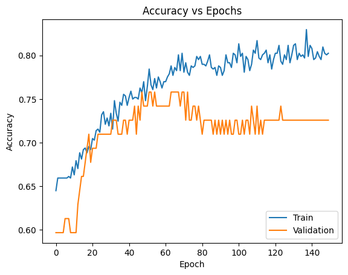

```python
plt.plot(history_1.history['accuracy'])
plt.plot(history_1.history['val_accuracy'])
plt.title('Accuracy vs Epochs')
plt.ylabel('Accuracy')
plt.xlabel('Epoch')
plt.legend(['Train', 'Validation'], loc='lower right')
plt.show()
```

- Observations
  - Training Accuracy steadily improves and peaks around 81%, indicating that the model learns well on the training data.
  - Validation Accuracy plateaus early at around 75% and begins to fluctuate, suggesting possible overfitting after ~60 epochs.
  - The gap between train and validation accuracy indicates that while the model generalizes reasonably well, further tuning (e.g., regularization or early stopping) may improve performance.

Model evaluation on the test data

```python
model_1.evaluate(X_test_normalized, y_test, verbose = 1)
test_pred = np.round(model_1.predict(X_test_normalized))
```

```
5/5 ━━━━━━━━━━━━━━━━━━━━ 0s 7ms/step - accuracy: 0.7047 - loss: 0.5523
5/5 ━━━━━━━━━━━━━━━━━━━━ 0s 15ms/step
```

- Observations
  - Test Accuracy: ~0.70
  - Test Loss: ~0.55
  - Performance is decent with moderate generalization.

### Model 2

Increase the model complexity by tuning some of the hyper-parameters to model performance

```python
# Clearing backend
from tensorflow.keras import backend
backend.clear_session()
```

```python
# Fixing the seed for random number generators
np.random.seed(42)

import random
random.seed(42)

tf.random.set_seed(42)
```

```python
model_2 = Sequential()
model_2.add(Dense(128, activation='tanh', input_shape=(8,)))  # Use 8 instead of 11
model_2.add(Dropout(0.1))
model_2.add(Dense(64, activation='tanh'))
model_2.add(Dropout(0.1))
model_2.add(Dense(32, activation='tanh'))
model_2.add(Dense(1, activation='sigmoid'))  # For binary classification
```

```python
model_2.compile(loss = 'binary_crossentropy', optimizer='adam', metrics=['accuracy'])
model_2.summary()
```

```
Model: "sequential"
```

```
┏━━━━━━━━━━━━━━━━━━━━━━━━━━━━━━━━━━━━━━┳━━━━━━━━━━━━━━━━━━━━━━━━━━━━━┳━━━━━━━━━━━━━━━━━┓
┃ Layer (type)                         ┃ Output Shape                ┃         Param # ┃
┡━━━━━━━━━━━━━━━━━━━━━━━━━━━━━━━━━━━━━━╇━━━━━━━━━━━━━━━━━━━━━━━━━━━━━╇━━━━━━━━━━━━━━━━━┩
│ dense (Dense)                        │ (None, 128)                 │           1,152 │
├──────────────────────────────────────┼─────────────────────────────┼─────────────────┤
│ dropout (Dropout)                    │ (None, 128)                 │               0 │
├──────────────────────────────────────┼─────────────────────────────┼─────────────────┤
│ dense_1 (Dense)                      │ (None, 64)                  │           8,256 │
├──────────────────────────────────────┼─────────────────────────────┼─────────────────┤
│ dropout_1 (Dropout)                  │ (None, 64)                  │               0 │
├──────────────────────────────────────┼─────────────────────────────┼─────────────────┤
│ dense_2 (Dense)                      │ (None, 32)                  │           2,080 │
├──────────────────────────────────────┼─────────────────────────────┼─────────────────┤
│ dense_3 (Dense)                      │ (None, 1)                   │              33 │
└──────────────────────────────────────┴─────────────────────────────┴─────────────────┘
```

```
 Total params: 11,521 (45.00 KB)
```

```
 Trainable params: 11,521 (45.00 KB)
```

```
 Non-trainable params: 0 (0.00 B)
```

```python
history_2 = model_2.fit(X_train_normalized,
                    y_train,
                    validation_split=0.1,
                    epochs=100,
                    verbose=2)
```

```
18/18 - 2s - 109ms/step - accuracy: 0.6304 - loss: 0.6722 - val_accuracy: 0.5968 - val_loss: 0.6549
18/18 - 0s - 7ms/step - accuracy: 0.6504 - loss: 0.6321 - val_accuracy: 0.6290 - val_loss: 0.6236
18/18 - 0s - 7ms/step - accuracy: 0.6630 - loss: 0.6144 - val_accuracy: 0.6935 - val_loss: 0.5896
18/18 - 0s - 7ms/step - accuracy: 0.6920 - loss: 0.5863 - val_accuracy: 0.7419 - val_loss: 0.5653
18/18 - 0s - 8ms/step - accuracy: 0.6975 - loss: 0.5668 - val_accuracy: 0.7097 - val_loss: 0.5439
18/18 - 0s - 7ms/step - accuracy: 0.7120 - loss: 0.5561 - val_accuracy: 0.7258 - val_loss: 0.5313
18/18 - 0s - 7ms/step - accuracy: 0.7174 - loss: 0.5426 - val_accuracy: 0.7258 - val_loss: 0.5252
18/18 - 0s - 8ms/step - accuracy: 0.7283 - loss: 0.5300 - val_accuracy: 0.7419 - val_loss: 0.5191
18/18 - 0s - 8ms/step - accuracy: 0.7319 - loss: 0.5222 - val_accuracy: 0.7419 - val_loss: 0.5123
18/18 - 0s - 7ms/step - accuracy: 0.7337 - loss: 0.5091 - val_accuracy: 0.7419 - val_loss: 0.5087
18/18 - 0s - 9ms/step - accuracy: 0.7482 - loss: 0.5014 - val_accuracy: 0.7581 - val_loss: 0.5040
18/18 - 0s - 12ms/step - accuracy: 0.7446 - loss: 0.5048 - val_accuracy: 0.7258 - val_loss: 0.5008
18/18 - 0s - 17ms/step - accuracy: 0.7591 - loss: 0.4944 - val_accuracy: 0.7258 - val_loss: 0.4987
18/18 - 0s - 11ms/step - accuracy: 0.7645 - loss: 0.4883 - val_accuracy: 0.7258 - val_loss: 0.4963
18/18 - 0s - 16ms/step - accuracy: 0.7736 - loss: 0.4893 - val_accuracy: 0.7258 - val_loss: 0.4964
18/18 - 0s - 11ms/step - accuracy: 0.7627 - loss: 0.4863 - val_accuracy: 0.7258 - val_loss: 0.4962
18/18 - 0s - 16ms/step - accuracy: 0.7627 - loss: 0.4916 - val_accuracy: 0.7419 - val_loss: 0.4979
18/18 - 0s - 18ms/step - accuracy: 0.7736 - loss: 0.4764 - val_accuracy: 0.7419 - val_loss: 0.4933
18/18 - 0s - 16ms/step - accuracy: 0.7736 - loss: 0.4745 - val_accuracy: 0.7419 - val_loss: 0.4905
18/18 - 0s - 18ms/step - accuracy: 0.7717 - loss: 0.4789 - val_accuracy: 0.7419 - val_loss: 0.4903
18/18 - 0s - 16ms/step - accuracy: 0.7663 - loss: 0.4821 - val_accuracy: 0.7419 - val_loss: 0.4936
18/18 - 0s - 17ms/step - accuracy: 0.7699 - loss: 0.4718 - val_accuracy: 0.7258 - val_loss: 0.4860
18/18 - 0s - 12ms/step - accuracy: 0.7754 - loss: 0.4702 - val_accuracy: 0.7419 - val_loss: 0.4867
18/18 - 0s - 8ms/step - accuracy: 0.7772 - loss: 0.4796 - val_accuracy: 0.7419 - val_loss: 0.4857
18/18 - 0s - 7ms/step - accuracy: 0.7699 - loss: 0.4715 - val_accuracy: 0.7419 - val_loss: 0.4873
18/18 - 0s - 8ms/step - accuracy: 0.7736 - loss: 0.4692 - val_accuracy: 0.7419 - val_loss: 0.4878
18/18 - 0s - 7ms/step - accuracy: 0.7609 - loss: 0.4667 - val_accuracy: 0.7742 - val_loss: 0.4820
18/18 - 0s - 7ms/step - accuracy: 0.7645 - loss: 0.4625 - val_accuracy: 0.7419 - val_loss: 0.4813
18/18 - 0s - 8ms/step - accuracy: 0.7681 - loss: 0.4657 - val_accuracy: 0.7581 - val_loss: 0.4789
18/18 - 0s - 7ms/step - accuracy: 0.7808 - loss: 0.4637 - val_accuracy: 0.7742 - val_loss: 0.4787
18/18 - 0s - 8ms/step - accuracy: 0.7772 - loss: 0.4648 - val_accuracy: 0.7581 - val_loss: 0.4792
18/18 - 0s - 8ms/step - accuracy: 0.7736 - loss: 0.4693 - val_accuracy: 0.7581 - val_loss: 0.4791
18/18 - 0s - 10ms/step - accuracy: 0.7808 - loss: 0.4578 - val_accuracy: 0.7258 - val_loss: 0.4794
18/18 - 0s - 15ms/step - accuracy: 0.7717 - loss: 0.4570 - val_accuracy: 0.7419 - val_loss: 0.4823
18/18 - 0s - 7ms/step - accuracy: 0.7790 - loss: 0.4578 - val_accuracy: 0.7419 - val_loss: 0.4806
18/18 - 0s - 8ms/step - accuracy: 0.7808 - loss: 0.4578 - val_accuracy: 0.7581 - val_loss: 0.4753
18/18 - 0s - 8ms/step - accuracy: 0.7808 - loss: 0.4604 - val_accuracy: 0.7742 - val_loss: 0.4757
18/18 - 0s - 7ms/step - accuracy: 0.7808 - loss: 0.4479 - val_accuracy: 0.7742 - val_loss: 0.4766
18/18 - 0s - 7ms/step - accuracy: 0.7663 - loss: 0.4614 - val_accuracy: 0.7581 - val_loss: 0.4738
18/18 - 0s - 8ms/step - accuracy: 0.7717 - loss: 0.4560 - val_accuracy: 0.7581 - val_loss: 0.4747
```

[output cut: 45 more lines]

```
18/18 - 0s - 7ms/step - accuracy: 0.7971 - loss: 0.4308 - val_accuracy: 0.7581 - val_loss: 0.5045
18/18 - 0s - 8ms/step - accuracy: 0.7808 - loss: 0.4422 - val_accuracy: 0.7419 - val_loss: 0.5016
18/18 - 0s - 10ms/step - accuracy: 0.7953 - loss: 0.4374 - val_accuracy: 0.7581 - val_loss: 0.5024
18/18 - 0s - 12ms/step - accuracy: 0.7826 - loss: 0.4319 - val_accuracy: 0.7581 - val_loss: 0.5002
18/18 - 0s - 12ms/step - accuracy: 0.8007 - loss: 0.4271 - val_accuracy: 0.7581 - val_loss: 0.5022
18/18 - 0s - 14ms/step - accuracy: 0.7862 - loss: 0.4303 - val_accuracy: 0.7581 - val_loss: 0.5032
18/18 - 0s - 17ms/step - accuracy: 0.7971 - loss: 0.4225 - val_accuracy: 0.7581 - val_loss: 0.5028
18/18 - 0s - 19ms/step - accuracy: 0.7935 - loss: 0.4261 - val_accuracy: 0.7581 - val_loss: 0.5027
18/18 - 0s - 12ms/step - accuracy: 0.7844 - loss: 0.4338 - val_accuracy: 0.7581 - val_loss: 0.5012
18/18 - 0s - 15ms/step - accuracy: 0.7808 - loss: 0.4206 - val_accuracy: 0.7581 - val_loss: 0.4985
18/18 - 0s - 19ms/step - accuracy: 0.7772 - loss: 0.4297 - val_accuracy: 0.7419 - val_loss: 0.4979
18/18 - 0s - 15ms/step - accuracy: 0.7899 - loss: 0.4290 - val_accuracy: 0.7419 - val_loss: 0.4978
18/18 - 0s - 17ms/step - accuracy: 0.7772 - loss: 0.4312 - val_accuracy: 0.7419 - val_loss: 0.5062
18/18 - 0s - 11ms/step - accuracy: 0.7862 - loss: 0.4282 - val_accuracy: 0.7581 - val_loss: 0.5071
18/18 - 0s - 7ms/step - accuracy: 0.7935 - loss: 0.4242 - val_accuracy: 0.7581 - val_loss: 0.5065
```

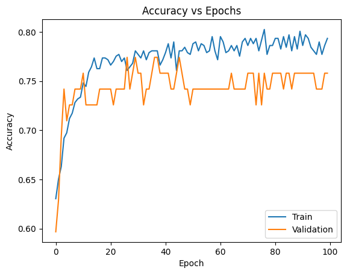

```python
plt.plot(history_2.history['accuracy'])
plt.plot(history_2.history['val_accuracy'])
plt.title('Accuracy vs Epochs')
plt.ylabel('Accuracy')
plt.xlabel('Epoch')
plt.legend(['Train', 'Validation'], loc='lower right')
plt.show()
```

- Observations
  - Steady Improvement: Both training and validation accuracy improve rapidly in the first 20 epochs.
  - Training Accuracy: Plateaus around 0.79–0.81, indicating strong learning.
  - Validation Accuracy: Stabilizes around 0.75, showing generalization is decent.
  - No Major Overfitting: The small gap between training and validation accuracy implies the model is not significantly overfitting.

Model evaluation on the test data

```python
model_2.evaluate(X_test_normalized, y_test, verbose = 1)
test_pred = np.round(model_2.predict(X_test_normalized))
```

```
5/5 ━━━━━━━━━━━━━━━━━━━━ 0s 8ms/step - accuracy: 0.7034 - loss: 0.5612
5/5 ━━━━━━━━━━━━━━━━━━━━ 0s 16ms/step
```

- Observations
  - Test Accuracy: ~0.70
  - Test Loss: ~0.56
  - Similar test accuracy to Model 1, with slightly higher loss.
  - Maintains its reputation for stability, but offers no advantage over Model 1 on unseen data.

### Model 3

Further hyperparameter tuning

- learning_rate = 0.001 for the optimizer in the training process and increase the model complexity by further increasing the number of layers, the number of nodes in each layer, and the epochs

```python
# Clearing the backend
from tensorflow.keras import backend
backend.clear_session()
```

```python
# Fixing the seed for random number generators
np.random.seed(42)

import random
random.seed(42)

tf.random.set_seed(42)
```

```python
model_3 = Sequential()
model_3.add(Dense(256, activation='tanh', input_shape=(8,)))
model_3.add(Dropout(0.1))
model_3.add(Dense(128, activation='tanh'))
model_3.add(Dropout(0.1))
model_3.add(Dense(64, activation='tanh'))
model_3.add(Dropout(0.1))
model_3.add(Dense(32, activation='tanh'))
model_3.add(Dense(1, activation='sigmoid'))
```

```python
model_3.compile(loss = 'binary_crossentropy', optimizer=tf.keras.optimizers.Adam(learning_rate=0.001), metrics=['accuracy'])
model_3.summary()
```

```
Model: "sequential"
```

```
┏━━━━━━━━━━━━━━━━━━━━━━━━━━━━━━━━━━━━━━┳━━━━━━━━━━━━━━━━━━━━━━━━━━━━━┳━━━━━━━━━━━━━━━━━┓
┃ Layer (type)                         ┃ Output Shape                ┃         Param # ┃
┡━━━━━━━━━━━━━━━━━━━━━━━━━━━━━━━━━━━━━━╇━━━━━━━━━━━━━━━━━━━━━━━━━━━━━╇━━━━━━━━━━━━━━━━━┩
│ dense (Dense)                        │ (None, 256)                 │           2,304 │
├──────────────────────────────────────┼─────────────────────────────┼─────────────────┤
│ dropout (Dropout)                    │ (None, 256)                 │               0 │
├──────────────────────────────────────┼─────────────────────────────┼─────────────────┤
│ dense_1 (Dense)                      │ (None, 128)                 │          32,896 │
├──────────────────────────────────────┼─────────────────────────────┼─────────────────┤
│ dropout_1 (Dropout)                  │ (None, 128)                 │               0 │
├──────────────────────────────────────┼─────────────────────────────┼─────────────────┤
│ dense_2 (Dense)                      │ (None, 64)                  │           8,256 │
├──────────────────────────────────────┼─────────────────────────────┼─────────────────┤
│ dropout_2 (Dropout)                  │ (None, 64)                  │               0 │
├──────────────────────────────────────┼─────────────────────────────┼─────────────────┤
│ dense_3 (Dense)                      │ (None, 32)                  │           2,080 │
├──────────────────────────────────────┼─────────────────────────────┼─────────────────┤
│ dense_4 (Dense)                      │ (None, 1)                   │              33 │
└──────────────────────────────────────┴─────────────────────────────┴─────────────────┘
```

```
 Total params: 45,569 (178.00 KB)
```

```
 Trainable params: 45,569 (178.00 KB)
```

```
 Non-trainable params: 0 (0.00 B)
```

```python
history_3 = model_3.fit(X_train_normalized,
                    y_train,
                    validation_split=0.1,
                    epochs=200,
                    verbose=2)
```

```
18/18 - 2s - 129ms/step - accuracy: 0.6250 - loss: 0.6768 - val_accuracy: 0.6129 - val_loss: 0.6344
18/18 - 0s - 24ms/step - accuracy: 0.6630 - loss: 0.6219 - val_accuracy: 0.6935 - val_loss: 0.5843
18/18 - 0s - 16ms/step - accuracy: 0.6830 - loss: 0.5910 - val_accuracy: 0.6935 - val_loss: 0.5499
18/18 - 0s - 8ms/step - accuracy: 0.7029 - loss: 0.5693 - val_accuracy: 0.7419 - val_loss: 0.5350
18/18 - 0s - 8ms/step - accuracy: 0.7101 - loss: 0.5506 - val_accuracy: 0.7419 - val_loss: 0.5258
18/18 - 0s - 9ms/step - accuracy: 0.7246 - loss: 0.5316 - val_accuracy: 0.7581 - val_loss: 0.5177
18/18 - 0s - 7ms/step - accuracy: 0.7482 - loss: 0.5147 - val_accuracy: 0.7581 - val_loss: 0.5078
18/18 - 0s - 8ms/step - accuracy: 0.7464 - loss: 0.5102 - val_accuracy: 0.7581 - val_loss: 0.5000
18/18 - 0s - 13ms/step - accuracy: 0.7591 - loss: 0.5022 - val_accuracy: 0.7419 - val_loss: 0.4898
18/18 - 0s - 23ms/step - accuracy: 0.7663 - loss: 0.4913 - val_accuracy: 0.7581 - val_loss: 0.4846
18/18 - 0s - 19ms/step - accuracy: 0.7591 - loss: 0.4841 - val_accuracy: 0.7581 - val_loss: 0.4855
18/18 - 0s - 9ms/step - accuracy: 0.7554 - loss: 0.4787 - val_accuracy: 0.7742 - val_loss: 0.4764
18/18 - 0s - 27ms/step - accuracy: 0.7663 - loss: 0.4670 - val_accuracy: 0.7581 - val_loss: 0.4764
18/18 - 0s - 25ms/step - accuracy: 0.7663 - loss: 0.4624 - val_accuracy: 0.7581 - val_loss: 0.4782
18/18 - 0s - 19ms/step - accuracy: 0.7826 - loss: 0.4574 - val_accuracy: 0.7742 - val_loss: 0.4787
18/18 - 0s - 16ms/step - accuracy: 0.7699 - loss: 0.4708 - val_accuracy: 0.7581 - val_loss: 0.4869
18/18 - 0s - 8ms/step - accuracy: 0.7826 - loss: 0.4637 - val_accuracy: 0.7419 - val_loss: 0.4830
18/18 - 0s - 8ms/step - accuracy: 0.7717 - loss: 0.4517 - val_accuracy: 0.7581 - val_loss: 0.4871
18/18 - 0s - 8ms/step - accuracy: 0.7826 - loss: 0.4583 - val_accuracy: 0.7419 - val_loss: 0.4873
18/18 - 0s - 8ms/step - accuracy: 0.7790 - loss: 0.4624 - val_accuracy: 0.7581 - val_loss: 0.4831
18/18 - 0s - 8ms/step - accuracy: 0.7572 - loss: 0.4567 - val_accuracy: 0.7419 - val_loss: 0.4991
18/18 - 0s - 7ms/step - accuracy: 0.7717 - loss: 0.4542 - val_accuracy: 0.7258 - val_loss: 0.4988
18/18 - 0s - 17ms/step - accuracy: 0.7790 - loss: 0.4608 - val_accuracy: 0.7258 - val_loss: 0.4898
18/18 - 0s - 8ms/step - accuracy: 0.7736 - loss: 0.4572 - val_accuracy: 0.7419 - val_loss: 0.4897
18/18 - 0s - 8ms/step - accuracy: 0.7790 - loss: 0.4551 - val_accuracy: 0.7419 - val_loss: 0.4937
18/18 - 0s - 12ms/step - accuracy: 0.7699 - loss: 0.4447 - val_accuracy: 0.7419 - val_loss: 0.4973
18/18 - 0s - 10ms/step - accuracy: 0.7699 - loss: 0.4572 - val_accuracy: 0.7419 - val_loss: 0.5029
18/18 - 0s - 12ms/step - accuracy: 0.7808 - loss: 0.4526 - val_accuracy: 0.7258 - val_loss: 0.5032
18/18 - 0s - 26ms/step - accuracy: 0.7736 - loss: 0.4624 - val_accuracy: 0.7419 - val_loss: 0.4940
18/18 - 1s - 37ms/step - accuracy: 0.7808 - loss: 0.4495 - val_accuracy: 0.7419 - val_loss: 0.4997
18/18 - 1s - 41ms/step - accuracy: 0.7772 - loss: 0.4418 - val_accuracy: 0.7419 - val_loss: 0.4948
18/18 - 1s - 35ms/step - accuracy: 0.7754 - loss: 0.4384 - val_accuracy: 0.7419 - val_loss: 0.5019
18/18 - 1s - 46ms/step - accuracy: 0.7844 - loss: 0.4451 - val_accuracy: 0.7258 - val_loss: 0.5072
18/18 - 0s - 18ms/step - accuracy: 0.7717 - loss: 0.4440 - val_accuracy: 0.7419 - val_loss: 0.5084
18/18 - 0s - 14ms/step - accuracy: 0.7935 - loss: 0.4403 - val_accuracy: 0.7419 - val_loss: 0.5071
18/18 - 0s - 15ms/step - accuracy: 0.7772 - loss: 0.4483 - val_accuracy: 0.7419 - val_loss: 0.5073
18/18 - 0s - 9ms/step - accuracy: 0.7772 - loss: 0.4464 - val_accuracy: 0.7419 - val_loss: 0.5077
18/18 - 0s - 16ms/step - accuracy: 0.7862 - loss: 0.4354 - val_accuracy: 0.7419 - val_loss: 0.5074
18/18 - 0s - 17ms/step - accuracy: 0.7736 - loss: 0.4420 - val_accuracy: 0.7581 - val_loss: 0.4918
18/18 - 0s - 10ms/step - accuracy: 0.7935 - loss: 0.4385 - val_accuracy: 0.7581 - val_loss: 0.4974
```

[output cut: 145 more lines]

```
18/18 - 0s - 8ms/step - accuracy: 0.8388 - loss: 0.3291 - val_accuracy: 0.7258 - val_loss: 0.6178
18/18 - 0s - 8ms/step - accuracy: 0.8569 - loss: 0.3229 - val_accuracy: 0.7097 - val_loss: 0.6184
18/18 - 0s - 8ms/step - accuracy: 0.8297 - loss: 0.3384 - val_accuracy: 0.7258 - val_loss: 0.6260
18/18 - 0s - 9ms/step - accuracy: 0.8406 - loss: 0.3343 - val_accuracy: 0.7258 - val_loss: 0.6186
18/18 - 0s - 8ms/step - accuracy: 0.8406 - loss: 0.3338 - val_accuracy: 0.7097 - val_loss: 0.6160
18/18 - 0s - 8ms/step - accuracy: 0.8478 - loss: 0.3312 - val_accuracy: 0.7097 - val_loss: 0.6242
18/18 - 0s - 8ms/step - accuracy: 0.8478 - loss: 0.3185 - val_accuracy: 0.7258 - val_loss: 0.6247
18/18 - 0s - 8ms/step - accuracy: 0.8442 - loss: 0.3375 - val_accuracy: 0.7258 - val_loss: 0.6232
18/18 - 0s - 7ms/step - accuracy: 0.8514 - loss: 0.3268 - val_accuracy: 0.7258 - val_loss: 0.6373
18/18 - 0s - 8ms/step - accuracy: 0.8551 - loss: 0.3191 - val_accuracy: 0.7258 - val_loss: 0.6416
18/18 - 0s - 8ms/step - accuracy: 0.8424 - loss: 0.3279 - val_accuracy: 0.7258 - val_loss: 0.6136
18/18 - 0s - 8ms/step - accuracy: 0.8533 - loss: 0.3159 - val_accuracy: 0.7258 - val_loss: 0.6272
18/18 - 0s - 8ms/step - accuracy: 0.8496 - loss: 0.3197 - val_accuracy: 0.7097 - val_loss: 0.6258
18/18 - 0s - 8ms/step - accuracy: 0.8442 - loss: 0.3183 - val_accuracy: 0.6935 - val_loss: 0.6366
18/18 - 0s - 8ms/step - accuracy: 0.8279 - loss: 0.3235 - val_accuracy: 0.7258 - val_loss: 0.6377
```

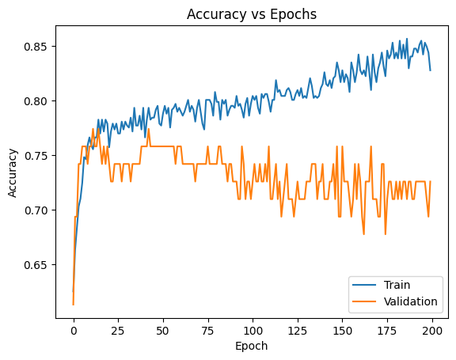

```python
plt.plot(history_3.history['accuracy'])
plt.plot(history_3.history['val_accuracy'])
plt.title('Accuracy vs Epochs')
plt.ylabel('Accuracy')
plt.xlabel('Epoch')
plt.legend(['Train', 'Validation'], loc='lower right')
plt.show()
```

Model evaluation on the test data

```python
model_3.evaluate(X_test_normalized, y_test, verbose = 1)
test_pred = np.round(model_3.predict(X_test_normalized))
```

```
5/5 ━━━━━━━━━━━━━━━━━━━━ 0s 10ms/step - accuracy: 0.6882 - loss: 0.6710
5/5 ━━━━━━━━━━━━━━━━━━━━ 0s 19ms/step
```

### Model 4

```python
# Clearing the backend
from tensorflow.keras import backend
backend.clear_session()
```

```python
# Fixing the seed for random number generators
np.random.seed(42)

import random
random.seed(42)

tf.random.set_seed(42)
```

```python
from tensorflow.keras.models import Sequential
from tensorflow.keras.layers import Dense, Dropout, BatchNormalization, Input

# Building Model 4
model_4 = Sequential()

# First hidden layer
model_4.add(Input(shape=(8,)))
model_4.add(Dense(128, activation='relu'))
model_4.add(BatchNormalization())
model_4.add(Dropout(0.3))

# Second hidden layer
model_4.add(Dense(64, activation='relu'))
model_4.add(BatchNormalization())
model_4.add(Dropout(0.2))

# Third hidden layer
model_4.add(Dense(32, activation='relu'))
model_4.add(Dropout(0.1))

# Output layer
model_4.add(Dense(1, activation='sigmoid'))

# Compile the model
model_4.compile(
    loss='binary_crossentropy',
    optimizer=tf.keras.optimizers.Adam(learning_rate=0.001),
    metrics=['accuracy']
)
```

```python
model_4.compile(loss = 'binary_crossentropy', optimizer=tf.keras.optimizers.Adam(learning_rate=0.001), metrics=['accuracy'])
model_4.summary()
```

```
Model: "sequential"
```

```
┏━━━━━━━━━━━━━━━━━━━━━━━━━━━━━━━━━━━━━━┳━━━━━━━━━━━━━━━━━━━━━━━━━━━━━┳━━━━━━━━━━━━━━━━━┓
┃ Layer (type)                         ┃ Output Shape                ┃         Param # ┃
┡━━━━━━━━━━━━━━━━━━━━━━━━━━━━━━━━━━━━━━╇━━━━━━━━━━━━━━━━━━━━━━━━━━━━━╇━━━━━━━━━━━━━━━━━┩
│ dense (Dense)                        │ (None, 128)                 │           1,152 │
├──────────────────────────────────────┼─────────────────────────────┼─────────────────┤
│ batch_normalization                  │ (None, 128)                 │             512 │
│ (BatchNormalization)                 │                             │                 │
├──────────────────────────────────────┼─────────────────────────────┼─────────────────┤
│ dropout (Dropout)                    │ (None, 128)                 │               0 │
├──────────────────────────────────────┼─────────────────────────────┼─────────────────┤
│ dense_1 (Dense)                      │ (None, 64)                  │           8,256 │
├──────────────────────────────────────┼─────────────────────────────┼─────────────────┤
│ batch_normalization_1                │ (None, 64)                  │             256 │
│ (BatchNormalization)                 │                             │                 │
├──────────────────────────────────────┼─────────────────────────────┼─────────────────┤
│ dropout_1 (Dropout)                  │ (None, 64)                  │               0 │
├──────────────────────────────────────┼─────────────────────────────┼─────────────────┤
│ dense_2 (Dense)                      │ (None, 32)                  │           2,080 │
├──────────────────────────────────────┼─────────────────────────────┼─────────────────┤
│ dropout_2 (Dropout)                  │ (None, 32)                  │               0 │
├──────────────────────────────────────┼─────────────────────────────┼─────────────────┤
│ dense_3 (Dense)                      │ (None, 1)                   │              33 │
└──────────────────────────────────────┴─────────────────────────────┴─────────────────┘
```

```
 Total params: 12,289 (48.00 KB)
```

```
 Trainable params: 11,905 (46.50 KB)
```

```
 Non-trainable params: 384 (1.50 KB)
```

```python
history_4 = model_4.fit(X_train_normalized,
                    y_train,
                    validation_split=0.1,
                    epochs=200,
                    verbose=2)
```

```
18/18 - 4s - 225ms/step - accuracy: 0.5580 - loss: 0.7576 - val_accuracy: 0.6452 - val_loss: 0.6704
18/18 - 0s - 16ms/step - accuracy: 0.7138 - loss: 0.5790 - val_accuracy: 0.5968 - val_loss: 0.6550
18/18 - 1s - 38ms/step - accuracy: 0.7174 - loss: 0.5320 - val_accuracy: 0.5968 - val_loss: 0.6458
18/18 - 0s - 21ms/step - accuracy: 0.7554 - loss: 0.5068 - val_accuracy: 0.5968 - val_loss: 0.6366
18/18 - 0s - 25ms/step - accuracy: 0.7790 - loss: 0.4868 - val_accuracy: 0.5968 - val_loss: 0.6257
18/18 - 0s - 8ms/step - accuracy: 0.7663 - loss: 0.4849 - val_accuracy: 0.5968 - val_loss: 0.6171
18/18 - 0s - 8ms/step - accuracy: 0.7736 - loss: 0.4838 - val_accuracy: 0.5968 - val_loss: 0.6095
18/18 - 0s - 8ms/step - accuracy: 0.7772 - loss: 0.4537 - val_accuracy: 0.5968 - val_loss: 0.6048
18/18 - 0s - 16ms/step - accuracy: 0.7428 - loss: 0.4883 - val_accuracy: 0.6290 - val_loss: 0.5982
18/18 - 0s - 8ms/step - accuracy: 0.7772 - loss: 0.4592 - val_accuracy: 0.6452 - val_loss: 0.5907
18/18 - 0s - 8ms/step - accuracy: 0.7790 - loss: 0.4602 - val_accuracy: 0.6613 - val_loss: 0.5830
18/18 - 0s - 8ms/step - accuracy: 0.7953 - loss: 0.4504 - val_accuracy: 0.6613 - val_loss: 0.5790
18/18 - 0s - 8ms/step - accuracy: 0.7862 - loss: 0.4612 - val_accuracy: 0.6774 - val_loss: 0.5733
18/18 - 0s - 8ms/step - accuracy: 0.7754 - loss: 0.4564 - val_accuracy: 0.6774 - val_loss: 0.5639
18/18 - 0s - 10ms/step - accuracy: 0.7953 - loss: 0.4347 - val_accuracy: 0.6935 - val_loss: 0.5638
18/18 - 0s - 10ms/step - accuracy: 0.7917 - loss: 0.4423 - val_accuracy: 0.6935 - val_loss: 0.5492
18/18 - 0s - 14ms/step - accuracy: 0.8043 - loss: 0.4259 - val_accuracy: 0.7097 - val_loss: 0.5363
18/18 - 0s - 17ms/step - accuracy: 0.7971 - loss: 0.4382 - val_accuracy: 0.7581 - val_loss: 0.5259
18/18 - 0s - 8ms/step - accuracy: 0.7844 - loss: 0.4370 - val_accuracy: 0.7419 - val_loss: 0.5169
18/18 - 0s - 8ms/step - accuracy: 0.7917 - loss: 0.4322 - val_accuracy: 0.7581 - val_loss: 0.5099
18/18 - 0s - 16ms/step - accuracy: 0.7899 - loss: 0.4296 - val_accuracy: 0.7742 - val_loss: 0.5113
18/18 - 0s - 16ms/step - accuracy: 0.7826 - loss: 0.4435 - val_accuracy: 0.7581 - val_loss: 0.5111
18/18 - 0s - 8ms/step - accuracy: 0.7971 - loss: 0.4227 - val_accuracy: 0.7742 - val_loss: 0.5139
18/18 - 0s - 8ms/step - accuracy: 0.8098 - loss: 0.4089 - val_accuracy: 0.7581 - val_loss: 0.5185
18/18 - 0s - 9ms/step - accuracy: 0.8007 - loss: 0.4107 - val_accuracy: 0.7581 - val_loss: 0.5129
18/18 - 0s - 8ms/step - accuracy: 0.7971 - loss: 0.4149 - val_accuracy: 0.7419 - val_loss: 0.5076
18/18 - 0s - 8ms/step - accuracy: 0.8406 - loss: 0.3692 - val_accuracy: 0.7742 - val_loss: 0.5129
18/18 - 0s - 8ms/step - accuracy: 0.8243 - loss: 0.3854 - val_accuracy: 0.7742 - val_loss: 0.5223
18/18 - 0s - 7ms/step - accuracy: 0.8152 - loss: 0.4037 - val_accuracy: 0.7419 - val_loss: 0.5049
18/18 - 0s - 10ms/step - accuracy: 0.8243 - loss: 0.3917 - val_accuracy: 0.7742 - val_loss: 0.5143
18/18 - 0s - 15ms/step - accuracy: 0.7989 - loss: 0.4299 - val_accuracy: 0.7742 - val_loss: 0.5267
18/18 - 0s - 8ms/step - accuracy: 0.8152 - loss: 0.4041 - val_accuracy: 0.7742 - val_loss: 0.5082
18/18 - 0s - 8ms/step - accuracy: 0.8152 - loss: 0.4007 - val_accuracy: 0.7742 - val_loss: 0.5122
18/18 - 0s - 17ms/step - accuracy: 0.7971 - loss: 0.4039 - val_accuracy: 0.7742 - val_loss: 0.5233
18/18 - 0s - 10ms/step - accuracy: 0.7971 - loss: 0.4067 - val_accuracy: 0.7419 - val_loss: 0.5091
18/18 - 0s - 17ms/step - accuracy: 0.7862 - loss: 0.3981 - val_accuracy: 0.7742 - val_loss: 0.4983
18/18 - 0s - 14ms/step - accuracy: 0.8261 - loss: 0.3869 - val_accuracy: 0.7419 - val_loss: 0.5166
18/18 - 0s - 8ms/step - accuracy: 0.8170 - loss: 0.3971 - val_accuracy: 0.7581 - val_loss: 0.5342
18/18 - 0s - 10ms/step - accuracy: 0.8098 - loss: 0.3830 - val_accuracy: 0.7419 - val_loss: 0.5397
18/18 - 0s - 7ms/step - accuracy: 0.8207 - loss: 0.3990 - val_accuracy: 0.7581 - val_loss: 0.5246
```

[output cut: 145 more lines]

```
18/18 - 0s - 7ms/step - accuracy: 0.9203 - loss: 0.1924 - val_accuracy: 0.7581 - val_loss: 0.8484
18/18 - 0s - 7ms/step - accuracy: 0.9203 - loss: 0.1841 - val_accuracy: 0.7581 - val_loss: 0.9144
18/18 - 0s - 8ms/step - accuracy: 0.9221 - loss: 0.1985 - val_accuracy: 0.7097 - val_loss: 0.9439
18/18 - 0s - 7ms/step - accuracy: 0.9130 - loss: 0.1884 - val_accuracy: 0.7742 - val_loss: 0.8927
18/18 - 0s - 8ms/step - accuracy: 0.9293 - loss: 0.1929 - val_accuracy: 0.7258 - val_loss: 0.9464
18/18 - 0s - 10ms/step - accuracy: 0.9203 - loss: 0.1760 - val_accuracy: 0.7581 - val_loss: 0.8428
18/18 - 0s - 14ms/step - accuracy: 0.9221 - loss: 0.1704 - val_accuracy: 0.8065 - val_loss: 0.9033
18/18 - 0s - 7ms/step - accuracy: 0.9330 - loss: 0.1727 - val_accuracy: 0.7742 - val_loss: 0.8570
18/18 - 0s - 8ms/step - accuracy: 0.9094 - loss: 0.1899 - val_accuracy: 0.7258 - val_loss: 0.8981
18/18 - 0s - 16ms/step - accuracy: 0.9149 - loss: 0.2009 - val_accuracy: 0.7258 - val_loss: 0.8052
18/18 - 0s - 7ms/step - accuracy: 0.9221 - loss: 0.1939 - val_accuracy: 0.7258 - val_loss: 0.8776
18/18 - 0s - 10ms/step - accuracy: 0.9384 - loss: 0.1674 - val_accuracy: 0.7097 - val_loss: 0.9049
18/18 - 0s - 11ms/step - accuracy: 0.9438 - loss: 0.1708 - val_accuracy: 0.7097 - val_loss: 0.9349
18/18 - 0s - 19ms/step - accuracy: 0.9275 - loss: 0.1845 - val_accuracy: 0.7258 - val_loss: 0.9984
18/18 - 0s - 21ms/step - accuracy: 0.9275 - loss: 0.1849 - val_accuracy: 0.7258 - val_loss: 0.9544
```

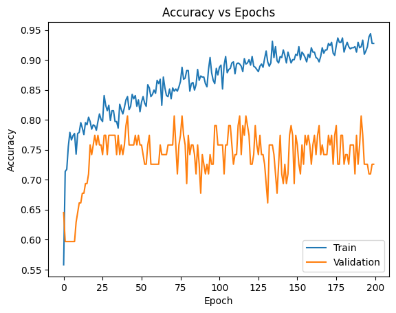

```python
plt.plot(history_4.history['accuracy'])
plt.plot(history_4.history['val_accuracy'])
plt.title('Accuracy vs Epochs')
plt.ylabel('Accuracy')
plt.xlabel('Epoch')
plt.legend(['Train', 'Validation'], loc='lower right')
plt.show()
```

Model evaluation on the test data

```python
model_4.evaluate(X_test_normalized, y_test, verbose = 1)
test_pred = np.round(model_4.predict(X_test_normalized))
```

```
5/5 ━━━━━━━━━━━━━━━━━━━━ 0s 13ms/step - accuracy: 0.6709 - loss: 1.1436
5/5 ━━━━━━━━━━━━━━━━━━━━ 0s 40ms/step
```

- Observations
  - Test Accuracy: ~0.67
  - Test Loss: ~1.14 (highest loss overall)
  - Despite improved training accuracy, generalization on test data is poor.
  - Indicates severe overfitting — model memorized training patterns but failed to generalize.
  - Not suitable for deployment without regularization or tuning.

## Conclusion

Best Performing Model (with Test Evaluation Considered): **Model 1**

After comparing training, validation, and **test accuracy**, **Model 1** stands out as the most **consistent performer**.  
Although **Model 4** had the highest training accuracy, it did **not generalize well on the test set**.

[output not shown]

Final Conclusion

> ✅ **Model 1** is recommended for deployment or further use, given its **balanced accuracy**, **low loss**, and **generalization to unseen data**.

```
5/5 ━━━━━━━━━━━━━━━━━━━━ 0s 14ms/step
              precision    recall  f1-score   support

           0       0.80      0.80      0.80        99
           1       0.64      0.64      0.64        55

    accuracy                           0.74       154
   macro avg       0.72      0.72      0.72       154
weighted avg       0.74      0.74      0.74       154
```

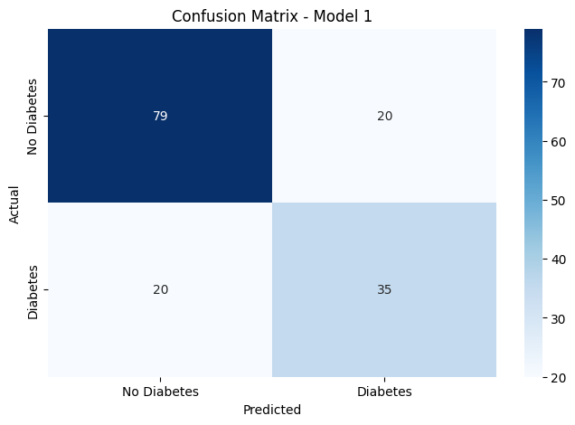

```python
from sklearn.metrics import classification_report, confusion_matrix
import seaborn as sns
import matplotlib.pyplot as plt

# Predict using Model 1
test_pred = np.round(model_1.predict(X_test_normalized))

# Classification report
print(classification_report(y_test, test_pred))

# Confusion matrix
cm = confusion_matrix(y_test, test_pred)

plt.figure(figsize=(8, 5))
sns.heatmap(cm, annot=True, fmt='d', cmap='Blues',
            xticklabels=['No Diabetes', 'Diabetes'],
            yticklabels=['No Diabetes', 'Diabetes'])
plt.title("Confusion Matrix - Model 1")
plt.ylabel('Actual')
plt.xlabel('Predicted')
plt.show()
```

- Observations
  - True Negatives (No Diabetes correctly predicted): 79
  - True Positives (Diabetes correctly predicted): 35
  - False Positives (No Diabetes misclassified as Diabetes): 20
  - False Negatives (Diabetes misclassified as No Diabetes): 20
- Model 1 shows balanced performance with similar error counts for both classes.
  - It handles both classes moderately well but leaves room for further improvement, especially in reducing false predictions.

## Recommendations

- Improve Recall: Misclassified 20 diabetes cases—consider adjusting the decision threshold or optimizing for recall.
- Handle Imbalance: If class imbalance exists, apply resampling or class weighting.
- Enhance Model: Add layers, dropout, or batch normalization to improve generalization.
- Tune Hyperparameters: Experiment with learning rate, epochs, and optimizer for better performance.
- Use Cross-Validation: Ensures model stability across different splits.
- Deployment Caution: Not reliable for real-world use without further improvement due to false negatives.

```python
# google

path_ipynb = '/content/drive/MyDrive/My DS DA/Neural Networks (Deep Learning)/Regression/Predicting Chance of Diabetes Deep Learning Regression.ipynb'
notebook_path = path_ipynb

!jupyter nbconvert --to html "{notebook_path}"

from google.colab import files
path_html = '/content/drive/MyDrive/My DS DA/Neural Networks (Deep Learning)/Regression/Predicting Chance of Diabetes Deep Learning Regression.html'

files.download(path_html)
```

```
[NbConvertApp] Converting notebook /content/drive/MyDrive/My DS DA/Neural Networks (Deep Learning)/Regression/Predicting Chance of Diabetes Deep Learning Regression.ipynb to html
[NbConvertApp] WARNING | Alternative text is missing on 7 image(s).
[NbConvertApp] Writing 979466 bytes to /content/drive/MyDrive/My DS DA/Neural Networks (Deep Learning)/Regression/Predicting Chance of Diabetes Deep Learning Regression.html
```